# Section 16: Linear Regression Inference

```r
library(tidyverse)
```

```r
# Set all plots in this section to have "minimal" theme - looks cleaner
theme_set(theme_minimal())
```

## CI for slope

The `summary` output of a linear model contains many useful values.

- “Residual standard error” is $S$, which estimates $\sigma$.
- Coefficient table shows standard error of slope (and intercept)

```r
riley <- read_table("../../data/riley.txt")
riley_2_8 <- riley %>%
  filter(age >= 24 & age <= 96)

n <- nrow(riley_2_8)

height_mod <- lm(height ~ age, data = riley_2_8)
summary(height_mod)
```

```
##
## Call:
## lm(formula = height ~ age, data = riley_2_8)
##
## Residuals:
##      Min       1Q   Median       3Q      Max
## -0.29911 -0.19291 -0.03355  0.21982  0.46334
##
## Coefficients:
##              Estimate Std. Error t value Pr(>|t|)
## (Intercept) 30.249329   0.186745  161.98   <2e-16 ***
## age          0.250519   0.002869   87.33   <2e-16 ***
## ---
## Signif. codes:  0 '***' 0.001 '**' 0.01 '*' 0.05 '.' 0.1 ' ' 1
##
## Residual standard error: 0.2429 on 14 degrees of freedom
## Multiple R-squared:  0.9982, Adjusted R-squared:  0.998
## F-statistic:  7627 on 1 and 14 DF,  p-value: < 2.2e-16
```

```r
# Verify standard error "by hand"
s <- summary(height_mod)$sigma

s / sqrt((n-1)*var(riley_2_8$age))
```

```
## [1] 0.002868531
```

```r
# Get summary measures from table
pt_est <- summary(height_mod)$coefficients[2, 1]
se <- summary(height_mod)$coefficients[2, 2]


cv <- qt(0.975, df = n - 2)

c(pt_est - cv*se, pt_est + cv*se)
```

```
## [1] 0.2443661 0.2566709
```

### Exercise

Build a 98% CI for the slope of the Lake Monona model.

```r
monona <- read_csv("../../data/lake-monona-winters-2025.csv")
lake_mod <- lm(duration ~ year1, data = monona)

n <- nrow(monona)
```

## Hypothesis test for slope

```r
pt_est <- summary(lake_mod)$coefficients[2, 1]
se <- summary(lake_mod)$coefficients[2, 2]

test_stat <- (pt_est - 0) / se

test_stat
```

```
## [1] -8.49658
```

This results in a significant p-value.

```r
# By default, pt finds a lower probability
pt(test_stat, df = n-2)
```

```
## [1] 5.034668e-15
```

What if it was two-sided? We would have the same test statistic and null distribution, but a different p-value. This matches the `summary` output.

```r
2*pt(test_stat, df = n-2)
```

```
## [1] 1.006934e-14
```

```r
summary(lake_mod)
```

```
##
## Call:
## lm(formula = duration ~ year1, data = monona)
##
## Residuals:
##     Min      1Q  Median      3Q     Max
## -54.616  -7.461   0.042  10.284  44.056
##
## Coefficients:
##              Estimate Std. Error t value Pr(>|t|)
## (Intercept) 537.01988   51.14308  10.500  < 2e-16 ***
## year1        -0.22398    0.02636  -8.497 1.01e-14 ***
## ---
## Signif. codes:  0 '***' 0.001 '**' 0.01 '*' 0.05 '.' 0.1 ' ' 1
##
## Residual standard error: 16.87 on 168 degrees of freedom
## Multiple R-squared:  0.3006, Adjusted R-squared:  0.2964
## F-statistic: 72.19 on 1 and 168 DF,  p-value: 1.007e-14
```

## Prediction intervals

```r
lions <- read_csv("../../data/lions.csv") %>%
  rename(black = proportion.black)
```

[output not shown]

```r
n <- nrow(lions)
```

[output not shown]

```r
# Fit a linear model with x = age, y = black
ggplot(lions, aes(age, black)) +
  geom_point() +
  geom_smooth(method = "lm", se = F)
```

[output not shown]

```r
lion_mod <- lm(black ~ age, data = lions)
```

[output not shown]

```r
summary(lion_mod)
```

[output not shown]

What would be the predicted % black on a 5 year old lion?

```r
predict(lion_mod, newdata = tibble(age = 5))
```

[output not shown]

```r
ggplot(lions, aes(x = age, y = black)) +
  geom_point() +
  geom_smooth(se = FALSE, method = "lm") +
  geom_point(aes(x=5, y=0.069696 + 5*0.058591), color="red", size=4) +
  geom_vline(xintercept = 5, color="red", linetype="dashed") +
  geom_hline(yintercept = 0.069696 + 5*0.058591, color = "red", linetype = "dashed")
```

[output not shown]

### Linear model simulation

The position of the line varies across samples. Take an (x, y) population with true intercept 5 and true slope 10.

Here’s an example of 100 different regression lines fit on 100 theoretical samples from the population.

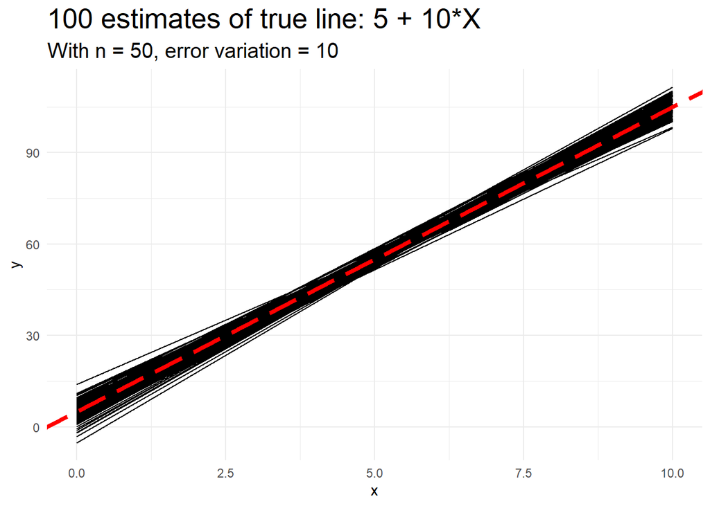

```r
simulateBestFitLines(error_sigma = 10)
```

As $\sigma$ is larger, the estimate for the linear model will have more uncertainty.

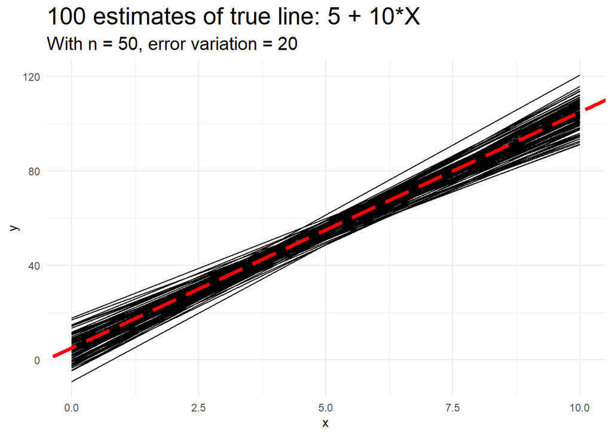

```r
simulateBestFitLines(error_sigma = 20)
```

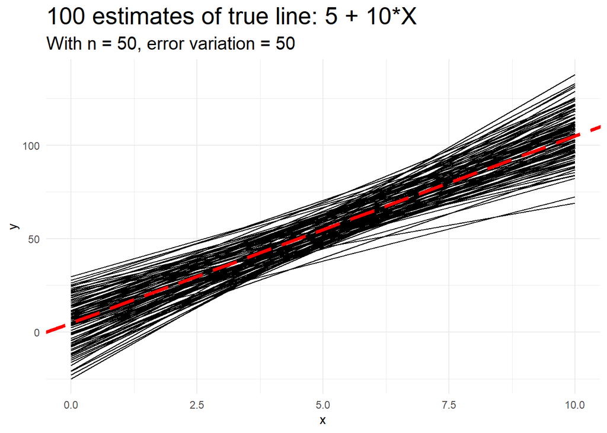

```r
simulateBestFitLines(error_sigma = 50)
```

### geom_smooth

The `geom_smooth` function is actually calculating lots of thin CIs around the fitted line.

```r
ggplot(lions, aes(age, black)) +
  geom_point() +
  geom_smooth(method = "lm")
```

[output not shown]

We can use `predict` to build the CI for us.

```r
predict(lion_mod, newdata = tibble(age = 5), interval = "confidence")
```

[output not shown]

Let’s verify our result by hand.

```r
pt_est <- predict(lion_mod, newdata = tibble(age = 5))
```

[output not shown]

```r
s <- summary(lion_mod)$sigma
```

[output not shown]

```r
se <- s*sqrt( 1/n + (5 - mean(lions$age))^2 / ((n-1)*var(lions$age)) )
```

[output not shown]

```r
cv <- qt(0.975, df = n-2)

c(pt_est - cv*se, pt_est + cv*se)
```

[output not shown]

With `predict()` as a shortcut, we can build many intervals.

```r
predict(lion_mod, newdata = tibble(age = 1:10))
```

[output not shown]

```r
lion_CIs <- predict(lion_mod, newdata = tibble(age = 1:13),
               interval = "confidence")
```

[output not shown]

```r
lion_CIs
```

[output not shown]

```r
ggplot(lions, aes(age, black)) +
  geom_point() +
  geom_line(data = as_tibble(lion_CIs), mapping = aes(x = 1:13, y = lwr), color = "darkgreen") +
  geom_line(data = as_tibble(lion_CIs), mapping = aes(x = 1:13, y = upr), color = "darkgreen") +
  geom_smooth(method = "lm") +
  labs(
    title = "Lion Ages vs. % nose black",
    subtitle = "With Confidence Regression Interval in Green"
  )  +
  theme(plot.title = element_text(size = 20),
        plot.subtitle = element_text(size = 15))
```

[output not shown]

### Predicting a new value

What is the estimated y for a *new* 5 year old lion? This is different than the prediction we did before.

```r
predict(lion_mod, newdata = tibble(age = 5), interval = "prediction")
```

[output not shown]

Let’s verify our result by hand.

```r
pt_est <- predict(lion_mod, newdata = tibble(age = 5))
```

[output not shown]

```r
s <- summary(lion_mod)$sigma
```

[output not shown]

```r
se <- s*sqrt(1 + 1/n + (5 - mean(lions$age))^2 / ((n-1)*var(lions$age)) )
```

[output not shown]

```r
cv <- qt(0.975, df = n-2)

c(pt_est - cv*se, pt_est + cv*se)
```

[output not shown]

```r
lion_PIs <- predict(lion_mod, newdata = tibble(age = 1:13),
               interval = "prediction")
```

[output not shown]

```r
lion_PIs
```

[output not shown]

```r
ggplot(lions, aes(age, black)) +
  geom_point() +
  geom_line(data = as_tibble(lion_PIs), mapping = aes(x = 1:13, y = lwr)) +
  geom_line(data = as_tibble(lion_PIs), mapping = aes(x = 1:13, y = upr)) +
  labs(
    title = "Lion Ages vs. % nose black",
    subtitle = "With Prediction Intervals"
  ) +
  theme(plot.title = element_text(size = 20),
        plot.subtitle = element_text(size = 15))
```

[output not shown]

```r
ggplot(lions, aes(age, black)) +
  geom_point() +
  geom_line(data = as_tibble(lion_PIs), mapping = aes(x = 1:13, y = lwr)) +
  geom_line(data = as_tibble(lion_PIs), mapping = aes(x = 1:13, y = upr)) +
  geom_line(data = as_tibble(lion_CIs), mapping = aes(x = 1:13, y = lwr), color = "darkgreen") +
  geom_line(data = as_tibble(lion_CIs), mapping = aes(x = 1:13, y = upr), color = "darkgreen") +
  geom_smooth(method = "lm") +
  labs(
    title = "Lion Ages vs. % nose black",
    subtitle = "With Prediction Intervals in Black, Confidence Regression Interval in Green"
  )  +
  theme(plot.title = element_text(size = 20),
        plot.subtitle = element_text(size = 15))
```

[output not shown]